# AS6_Richard Yang

Zhilin Yang

2023-07-22

```r
library(tseries)
library(ggplot2)
library(forecast)
library(tframePlus)
library(fpp)
```

## Question 1:

Load and plot the visitors dataset and plot the dataset with and without the Box Cox transformation. Describe the main dataset characteristics.

```r
setwd('C:/Users/Richa/Desktop/TS/week6/')
load(file = "visitors_monthly.rda")
df_raw  <- ts(visitors$x, start= c(1985,5),end=c(2005,4), frequency = 12)
```

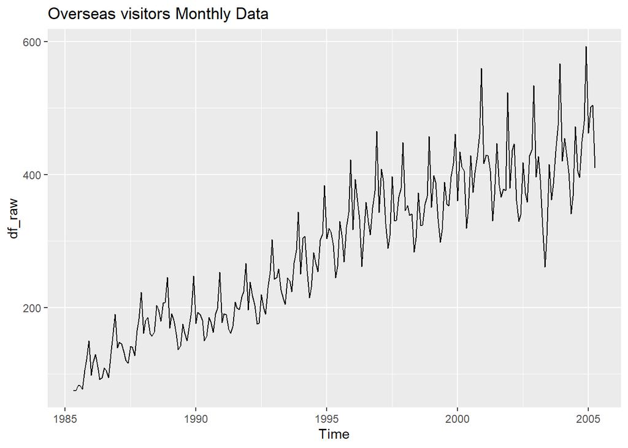

```r
autoplot(df_raw, main = 'Overseas visitors Monthly Data')
```

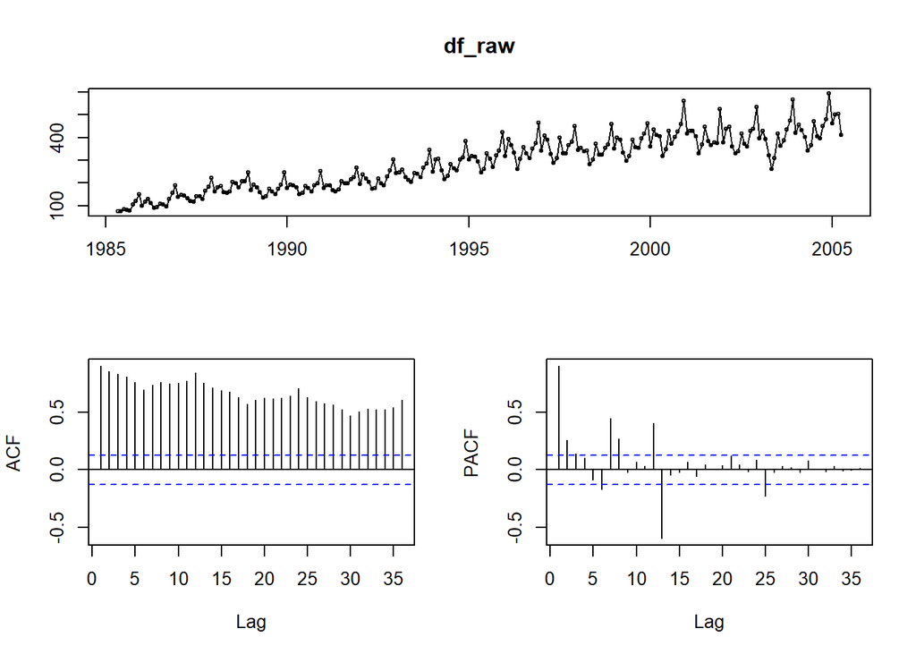

```r
tsdisplay(df_raw)
```

```r
lambda_value = BoxCox.lambda(df_raw)
lambda_value
```

```
## [1] 0.2775249
```

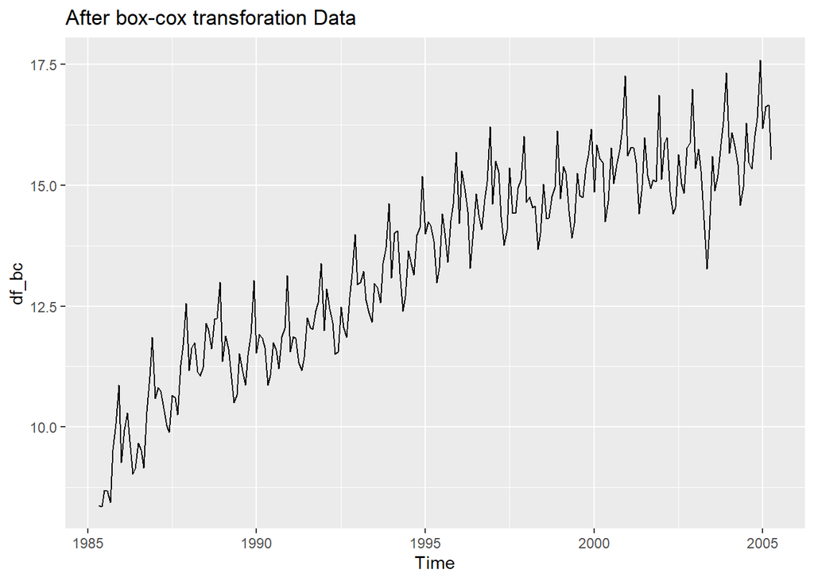

```r
df_bc = BoxCox(df_raw,lambda_value)
autoplot(df_bc,main = 'After box-cox transforation Data')
```

Dataset Characteristics:

Before Box-Cox transformation, there is a clear seasonality trend with non-constant variance.

After Box-Cox transformation, there magnitude of increment in the plot become consistant, indicating a more constant variance

## Question 2:

Build two models using the entire visitors dataset

1. Model 1: Let the auto.arima() function determine the best order 𝐴𝑅𝐼𝑀𝐴(𝑝, 𝑑, 𝑞)(𝑃,𝑄,𝐷)𝑠 model.
2. Model 2: Let the ets() function determine the best model for exponential smoothing.

```r
model1 = auto.arima(df_raw, seasonal = TRUE, lambda = lambda_value)
model1
```

```
## Series: df_raw
## ARIMA(0,1,1)(2,1,1)[12]
## Box Cox transformation: lambda= 0.2775249
##
## Coefficients:
##           ma1     sar1     sar2     sma1
##       -0.3111  -0.2852  -0.1860  -0.5353
## s.e.   0.0684   0.1501   0.1123   0.1558
##
## sigma^2 = 0.06172:  log likelihood = -9.07
## AIC=28.14   AICc=28.41   BIC=45.27
```

```r
model2 = ets(df_raw, lambda = lambda_value)
model2
```

```
## ETS(A,A,A)
##
## Call:
##  ets(y = df_raw, lambda = lambda_value)
##
##   Box-Cox transformation: lambda= 0.2775
##
##   Smoothing parameters:
##     alpha = 0.613
##     beta  = 1e-04
##     gamma = 0.1629
##
##   Initial states:
##     l = 9
##     b = 0.029
##     s = -0.2608 0.2417 0.2399 -0.1191 1.4225 0.5071
##            0.1414 -0.6578 -0.1895 0.0663 -0.5966 -0.7949
##
##   sigma:  0.2493
##
##      AIC     AICc      BIC
## 665.9353 668.6921 725.1062
```

## Question 3:

In this section you will apply the time-series cross validation method to train and test various models. Use the following values when training and testing the models:

For each iteration, apply the following 4 forecasts: 1) Use the Arima() function to estimate a SARIMA([1,0,1][0,1,2]12 with drift model for: a. Expanding training window and b. Sliding training window 2) Use the Exponential Smoothing function ets() to estimate a MAM (Multiplicative Error, Additive trend, multiplicative Season) model for: a. Expanding training window b. Sliding training window For each test window record the: 1) One-year forecast horizon error 2) Estimated model AICc value. For each of the four models above, calculate and plot the 1) Mean Absolute Forecast Error (MAE) vs forecast horizon. 2) Root-square Forecast Error (RMSE) vs forecast horizon. 3) AICc vs iteration number Discuss your results.

```r
# Set initials
k <- 160 # minimum data length for fitting a model
n <- length(df_raw) # Number of data points
p <- 12 ### Period
H <- 12 # Forecast Horiz
initTime <- tsp(df_raw)[1]+(k-2)/p #  gives the start time in time units
```

```r
origWarn <- getOption("warn")
options(warn = -1)

Ar_maeExp <- matrix(NA,n-k,H)
Ar_maeSlide <- matrix(NA,n-k,H)
Ar_RMSEExp <- matrix(NA,n-k,H)
Ar_RMSESlide <- matrix(NA,n-k,H)
Ar_aiccExp <- matrix(NA,n-k,1)
Ar_aiccSlide <- matrix(NA,n-k,1)

Ets_maeExp <- matrix(NA,n-k,H)
Ets_maeSlide <- matrix(NA,n-k,H)
Ets_rmseExp <- matrix(NA,n-k,H)
Ets_rmseSlide <- matrix(NA,n-k,H)
Ets_aiccExp <- matrix(NA,n-k,1)
Ets_aiccSlide <- matrix(NA,n-k,1)

for(i in 1:(n-k))
{
  # Expanding Window
  train_1_ar <- window(df_raw, end=initTime + i/p)
  train_1_ets <- window(df_raw, end=initTime + i/p)

  # Sliding Window
  train_2_ar <- window(df_raw, start=initTime+(i-k+1)/p, end=initTime+i/p)
  train_2_ets <- window(df_raw, start=initTime+(i-k+1)/p, end=initTime+i/p)

  test_ar <- window(df_raw, start=initTime + (i+1)/p, end=initTime + (i+H)/p)
  test_ets <- window(df_raw, start=initTime + (i+1)/p, end=initTime + (i+H)/p)

  if (i<4) {
    cat(c("*** CV", i,":","len(Expanding Window):",length(train_1_ar), "len(Sliding Window):",length(train_2_ar), "len(Test):",length(test_ar),'\n'  ))
    cat(c("*** TRAIN -  Expanding Window:",tsp(train_1_ar)[1],'-',tsp(train_1_ar)[2],'\n'))
    cat(c("*** TRAIN - Sliding Window:",tsp(train_2_ar)[1],'-',tsp(train_2_ar)[2],'\n'))
    cat(c("*** TEST:",tsp(test_ar)[1],'-',tsp(test_ar)[2],'\n'))
    cat("*************************** \n \n")
  }

  # Arima model training and forecasting
  fit_Exp_ar <- Arima(train_1_ar, order=c(1,0,1), seasonal=list(order=c(0,1,2), period=p),
                include.drift=TRUE, lambda=lambda_value, method="ML")
  fcast_Exp_ar <- forecast(fit_Exp_ar, h=H)

  fit_Slide_ar <- Arima(train_2_ar, order=c(1,0,1), seasonal=list(order=c(0,1,2), period=p),
                include.drift=TRUE, lambda=lambda_value, method="ML")
  fcast_Slide_ar <- forecast(fit_Slide_ar, h=H)

  # ETS model training and forecasting
  fit_Exp_ets <- ets(train_1_ets, model = "MAM")
  fcast_Exp_ets <- forecast(fit_Exp_ets, h=12)

  fit_Slide_ets <- ets(train_2_ets, model = "MAM")
  fcast_Slide_ets <- forecast(fit_Slide_ets, h=12)

  # Error calculations
  Ar_maeExp[i,1:length(test_ar)] <- abs(fcast_Exp_ar[['mean']]-test_ar)
  Ar_maeSlide[i,1:length(test_ar)] <- abs(fcast_Slide_ar[['mean']]-test_ar)
  Ar_RMSEExp[i,1:length(test_ar)] <- sqrt(mean((fcast_Exp_ar[['mean']]-test_ar)^2))
  Ar_RMSESlide[i,1:length(test_ar)] <- sqrt(mean((fcast_Slide_ar[['mean']]-test_ar)^2))
  Ar_aiccExp[i] <- fit_Exp_ar$aicc
  Ar_aiccSlide[i] <- fit_Slide_ar$aicc

  Ets_maeExp[i,1:length(test_ets)] <- abs(fcast_Exp_ets[['mean']]-test_ets)
  Ets_maeSlide[i,1:length(test_ets)] <- abs(fcast_Slide_ets[['mean']]-test_ets)
  Ets_rmseExp[i,1:length(test_ets)] <- sqrt(mean((fcast_Exp_ets[['mean']]-test_ets)^2))
  Ets_rmseSlide[i,1:length(test_ets)] <- sqrt(mean((fcast_Slide_ets[['mean']]-test_ets)^2))
  Ets_aiccExp[i] <- fit_Exp_ets$aicc
  Ets_aiccSlide[i] <- fit_Slide_ets$aicc
}
```

```
## *** CV 1 : len(Expanding Window): 160 len(Sliding Window): 160 len(Test): 12
## *** TRAIN -  Expanding Window: 1985.33333333333 - 1998.58333333333
## *** TRAIN - Sliding Window: 1985.33333333333 - 1998.58333333333
## *** TEST: 1998.66666666667 - 1999.58333333333
##
## *** CV 2 : len(Expanding Window): 161 len(Sliding Window): 160 len(Test): 12
## *** TRAIN -  Expanding Window: 1985.33333333333 - 1998.66666666667
## *** TRAIN - Sliding Window: 1985.41666666667 - 1998.66666666667
## *** TEST: 1998.75 - 1999.66666666667
##
## *** CV 3 : len(Expanding Window): 162 len(Sliding Window): 160 len(Test): 12
## *** TRAIN -  Expanding Window: 1985.33333333333 - 1998.75
## *** TRAIN - Sliding Window: 1985.5 - 1998.75
## *** TEST: 1998.83333333333 - 1999.75
##
```

```r
options(warn = origWarn)
```

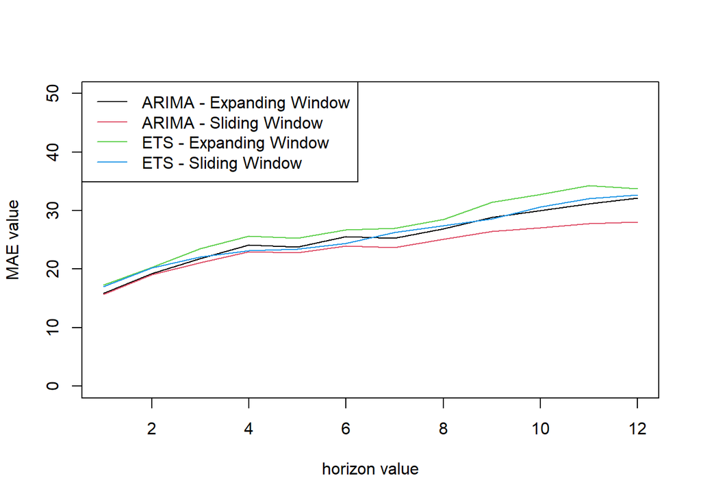

```r
plot(1:12, colMeans(Ar_maeExp,na.rm=TRUE), type="l",col=1,xlab="horizon value", ylab="MAE value",ylim=c(0,50))
lines(1:12, colMeans(Ar_maeSlide,na.rm=TRUE), type="l",col=2)
lines(1:12, colMeans(Ets_maeExp,na.rm=TRUE), type="l",col=3)
lines(1:12, colMeans(Ets_maeSlide,na.rm=TRUE), type="l",col=4)
legend("topleft",legend=c("ARIMA - Expanding Window","ARIMA - Sliding Window", "ETS - Expanding Window","ETS - Sliding Window"),col=1:4,lty=1)
```

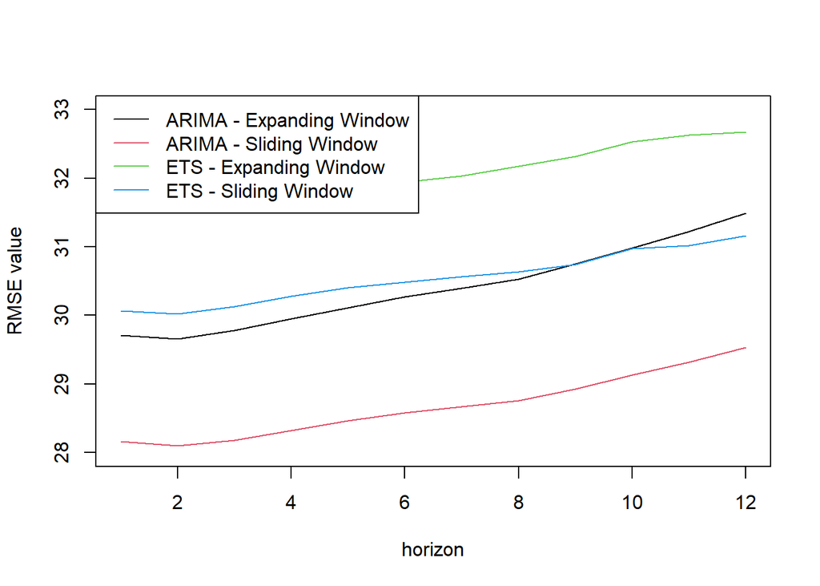

```r
plot(1:12, colMeans(Ar_RMSEExp,na.rm=TRUE), type="l",col=1,xlab="horizon", ylab="RMSE value",ylim=c(28,33))
lines(1:12, colMeans(Ar_RMSESlide,na.rm=TRUE), type="l",col=2)
lines(1:12, colMeans(Ets_rmseExp,na.rm=TRUE), type="l",col=3)
lines(1:12, colMeans(Ets_rmseSlide,na.rm=TRUE), type="l",col=4)
legend("topleft",legend=c("ARIMA - Expanding Window","ARIMA - Sliding Window", "ETS - Expanding Window","ETS - Sliding Window"),col=1:4,lty=1)
```

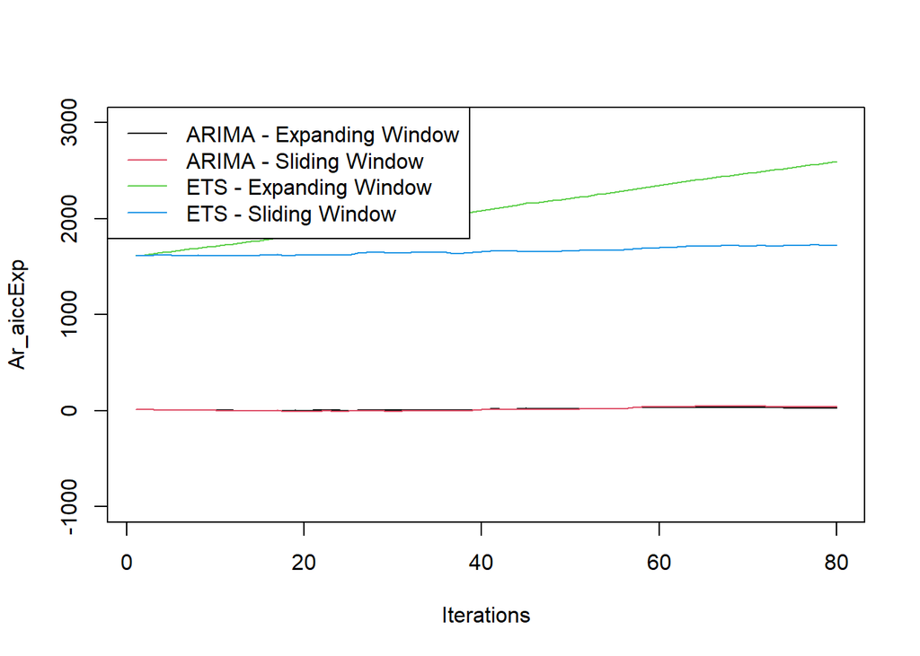

```r
plot(1:80, Ar_aiccExp, type="l",col=1,xlab="Iterations",ylim=c(-1000,3000))
lines(1:80, Ar_aiccSlide, type="l",col=2)
lines(1:80, Ets_aiccExp, type="l",col=3)
lines(1:80, Ets_aiccSlide, type="l",col=4)
legend("topleft",legend=c("ARIMA - Expanding Window","ARIMA - Sliding Window", "ETS - Expanding Window","ETS - Sliding Window"),col=1:4,lty=1)
```

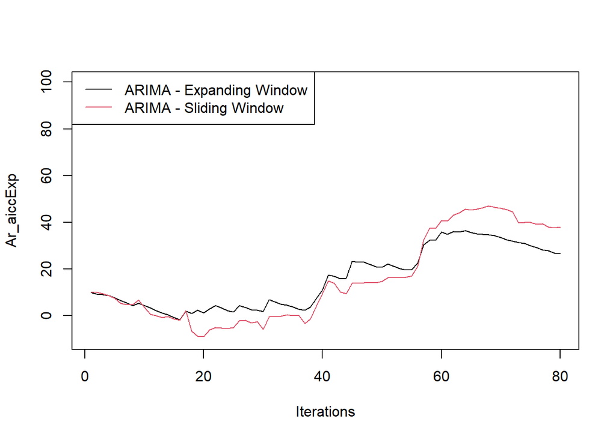

```r
plot(1:80, Ar_aiccExp, type="l",col=1,xlab="Iterations",ylim=c(-10,100))
lines(1:80, Ar_aiccSlide, type="l",col=2)
legend("topleft",legend=c("ARIMA - Expanding Window","ARIMA - Sliding Window"),col=1:2,lty=1)
```

Therefore, in the question, Arima model has a generally better performace than the ETS model

## Question 4:

What are the disadvantages of the above methods? What would be a better approach to estimate the models? Hint: How were the SARIMA and exponential time series models determined in question 3?

1. The current implementation of SARIMA and exponential time series models incrementally adds one data point to the training set in each iteration, which results in a time-consuming process. As an alternative, we could advance the training set by 12 observations at each step. This approach is particularly beneficial for large data sets, as it allows for the application of k-fold cross-validation where the training sets enlarge by multiple data points at once.
2. Errors that rely on a specific scale, including metrics like ME, MPE, and RMSE, are limited because they don’t accommodate comparisons across different scales.
3. Although the AICc proves beneficial for selecting the best model within a particular class, it lacks the ability to compare models across different classes. For instance, we cannot accurately compare the ETS and ARIMA models using AICc since they belong to distinct classes, and their likelihoods are calculated differently.

Therefore, to enhance our model, we could consider adjusting our training set expansion strategy by incrementing by 12 observations instead of one for each iteration, especially for larger datasets. It’s also necessary to rethink our evaluation metrics, acknowledging the constraints of scale-dependent metrics and the limitations of AICc for cross-class model comparisons. Alternative, more appropriate techniques should be explored for model comparison and performance evaluation.